# Proyecto_Entrega2_Presentación_Resultados

- Luis Pedro Lira (23669) - Fernando Rocha (23501) - Juan Francisco Martínez (23617) - Luis Gilberto González (23353) - Joel Antonio Jaquez (23369)

2026-05-01

# Actividad 5: Conjuntos de entrenamiento y prueba

## Método de validación

Dado que el conjunto de datos está agregado a nivel departamental y cuenta con únicamente 22 observaciones, no es posible aplicar una partición fija tradicional de entrenamiento y prueba. Con una división estándar 80/20 el conjunto de prueba quedaría con apenas 4 departamentos, lo que haría que los resultados dependieran fuertemente de cuáles cayeron en cada partición.

Por esta razón se utilizó **Leave-One-Out Cross Validation (LOOCV)**. En cada iteración el modelo se entrena con 21 departamentos y se evalúa en el departamento restante, repitiendo el proceso 22 veces hasta que todos los departamentos hayan sido usados exactamente una vez como prueba. Las métricas finales se calculan promediando los errores de las 22 iteraciones, lo que produce una estimación más honesta del error de generalización sin desperdiciar observaciones.

Como la variable respuesta es cuantitativa, **no aplica el concepto de balance de clases**. En su lugar se analiza la presencia de valores atípicos con alta influencia sobre el modelo.

```r
n_obs      <- nrow(datos_modelo)
porc_train <- (n_obs - 1) / n_obs * 100
porc_test  <- 1 / n_obs * 100

tibble(
  `N observaciones`               = n_obs,
  `% entrenamiento por iteración` = round(porc_train, 2),
  `% prueba por iteración`        = round(porc_test, 2)
) %>%
  kable(caption = "Proporciones de entrenamiento y prueba bajo LOOCV")
```

Proporciones de entrenamiento y prueba bajo LOOCV

| N observaciones | % entrenamiento por iteración | % prueba por iteración |
| --- | --- | --- |
| 22 | 95.45 | 4.55 |

En cada iteración se usa el **95.45%** de los datos para entrenamiento y el **4.55%** para prueba.

## Análisis de atípicos

Al tratarse de un problema de regresión con variable respuesta cuantitativa, se analiza la distribución de `casos_divorcio` para identificar observaciones con comportamiento extremo que puedan influir desproporcionadamente en los modelos.

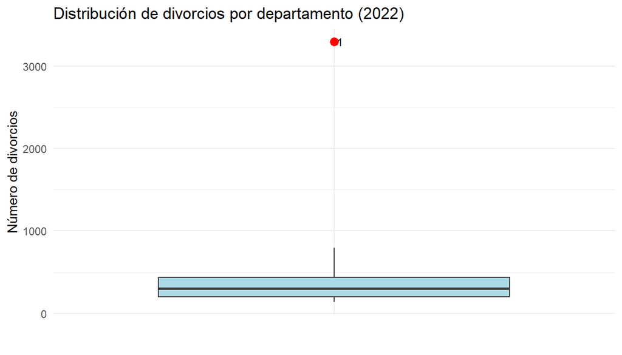

Distribución de divorcios por departamento. El punto rojo corresponde al Departamento de Guatemala, cuyo volumen es extremadamente superior al resto del país.

```r
ggplot(datos_modelo, aes(x = "", y = casos_divorcio)) +
  geom_boxplot(fill = "lightblue", outlier.color = "red",
               outlier.size = 3) +
  geom_text(
    data = datos_modelo %>% filter(casos_divorcio > 1000),
    aes(label = cod_depto),
    hjust = -0.5, size = 3
  ) +
  labs(
    title = "Distribución de divorcios por departamento (2022)",
    x     = "",
    y     = "Número de divorcios"
  ) +
  theme_minimal()
```

```r
datos_modelo %>%
  arrange(desc(casos_divorcio)) %>%
  select(cod_depto, casos_divorcio) %>%
  mutate(
    z_score = round(
      (casos_divorcio - mean(casos_divorcio)) / sd(casos_divorcio), 2
    )
  ) %>%
  kable(caption = "Departamentos ordenados por divorcios con z-score")
```

Departamentos ordenados por divorcios con z-score

| cod_depto | casos_divorcio | z_score |
| --- | --- | --- |
| 1 | 3295 | 4.34 |
| 9 | 794 | 0.52 |
| 12 | 565 | 0.17 |
| 5 | 497 | 0.07 |
| 10 | 485 | 0.05 |
| 13 | 450 | 0.00 |
| 22 | 402 | -0.08 |
| 11 | 331 | -0.19 |
| 17 | 326 | -0.19 |
| 6 | 316 | -0.21 |
| 14 | 314 | -0.21 |
| 18 | 286 | -0.25 |
| 21 | 238 | -0.33 |
| 20 | 212 | -0.37 |
| 4 | 210 | -0.37 |
| 8 | 201 | -0.38 |
| 16 | 198 | -0.39 |
| 19 | 195 | -0.39 |
| 2 | 179 | -0.42 |
| 3 | 174 | -0.42 |
| 15 | 145 | -0.47 |
| 7 | 137 | -0.48 |

Este departamento no se elimina del análisis porque es una observación real y relevante para el problema. En su lugar se controla mediante la variable dummy `es_capital`, que se detalla en la siguiente sección.

# Actividad 6: Preprocesamiento y preparación de datos

Esta sección describe todas las transformaciones aplicadas a los datos antes de entrenar los modelos. El resultado final es el objeto `datos_modelo`, que será utilizado por todos los algoritmos en las actividades 7 y 8.

## Carga y filtro por año

Los archivos fuente del INE contienen registros del período 2012 a 2022. Se filtra únicamente el año **2022** para garantizar un análisis de corte transversal limpio, donde cada departamento representa una observación bajo condiciones temporales homogéneas. Mezclar múltiples años sin modelar la estructura temporal produciría conteos inflados sin interpretación válida para un modelo de regresión de corte transversal.

```r
cat("Registros de divorcios (2022):", nrow(divorcios_raw), "\n")
```

```
## Registros de divorcios (2022): 9950
```

```r
cat("Registros de violencia (2022):", nrow(violencia_raw), "\n")
```

```
## Registros de violencia (2022): 37194
```

## Limpieza y recodificación

Los archivos del INE utilizan los códigos 99 y 999 para representar información no especificada. Estos valores se transforman en `NA` para evitar que distorsionen los cálculos. Adicionalmente, los registros con código departamental 99 se excluyen porque no pueden asignarse a ninguna unidad geográfica válida.

## Agregación departamental y selección de covariables

Los microdatos individuales se agrupan por departamento. Se calculan tres covariables a partir del dataset de violencia:

- **`casos_violencia`**: conteo total de casos de violencia intrafamiliar.
- **`edad_victima_prom`**: edad promedio de la víctima como proxy del perfil etario departamental.
- **`porc_urbano`**: proporción de casos en área urbana como proxy de urbanización.

La variable `hijos_prom` fue evaluada y descartada por presentar una correlación prácticamente nula con la variable respuesta (r = 0.095), lo que indica que no aporta capacidad predictiva al modelo.

```r
cat("Departamentos en violencia:", nrow(violencia_dep), "\n")
```

```
## Departamentos en violencia: 22
```

```r
cat("Departamentos en divorcios:", nrow(divorcios_dep), "\n")
```

```
## Departamentos en divorcios: 22
```

## Transformaciones aplicadas al dataset final

Una vez construido el dataset con las variables base, se aplicaron dos transformaciones adicionales:

**Estandarización z-score.** Las variables continuas (`casos_violencia`, `edad_victima_prom`, `porc_urbano`) se transformaron a z-score, restando la media y dividiendo por la desviación estándar. Esto permite comparar directamente la magnitud de los coeficientes entre predictores con escalas distintas y mejora la estabilidad numérica de los algoritmos.

**Variable dummy `es_capital`.** El análisis exploratorio identificó al Departamento de Guatemala como un outlier estructural extremo. Esta variable binaria vale 1 para ese departamento y 0 para los demás, permitiendo que los modelos capturen su diferencia estructural sin eliminarlo del análisis.

## Dataset final de modelado

```r
datos_modelo %>%
  select(cod_depto, casos_divorcio, casos_violencia,
         edad_victima_prom, porc_urbano, es_capital) %>%
  kable(digits = 2,
        caption = "Dataset de modelado: variables originales por departamento (2022)")
```

Dataset de modelado: variables originales por departamento (2022)

| cod_depto | casos_divorcio | casos_violencia | edad_victima_prom | porc_urbano | es_capital |
| --- | --- | --- | --- | --- | --- |
| 1 | 3295 | 8268 | 39.46 | 0.88 | 1 |
| 2 | 179 | 1122 | 38.78 | 0.40 | 0 |
| 3 | 174 | 1689 | 36.18 | 0.73 | 0 |
| 4 | 210 | 2169 | 34.47 | 0.66 | 0 |
| 5 | 497 | 1745 | 33.18 | 0.70 | 0 |
| 6 | 316 | 1126 | 35.23 | 0.32 | 0 |
| 7 | 137 | 355 | 40.12 | 0.32 | 0 |
| 8 | 201 | 462 | 35.41 | 0.26 | 0 |
| 9 | 794 | 2106 | 36.77 | 0.61 | 0 |
| 10 | 485 | 1765 | 35.63 | 0.45 | 0 |
| 11 | 331 | 1575 | 32.08 | 0.37 | 0 |
| 12 | 565 | 1703 | 37.37 | 0.29 | 0 |
| 13 | 450 | 999 | 36.04 | 0.34 | 0 |
| 14 | 314 | 629 | 36.01 | 0.35 | 0 |
| 15 | 145 | 1331 | 37.43 | 0.37 | 0 |
| 16 | 198 | 4561 | 33.86 | 0.43 | 0 |
| 17 | 326 | 1043 | 34.37 | 0.80 | 0 |
| 18 | 286 | 918 | 35.26 | 0.51 | 0 |
| 19 | 195 | 903 | 38.00 | 0.49 | 0 |
| 20 | 212 | 475 | 37.07 | 0.56 | 0 |
| 21 | 238 | 456 | 35.27 | 0.47 | 0 |
| 22 | 402 | 1245 | 38.21 | 0.26 | 0 |

```r
datos_modelo %>%
  select(casos_divorcio, casos_violencia,
         edad_victima_prom, porc_urbano) %>%
  summary()
```

```
##  casos_divorcio   casos_violencia  edad_victima_prom  porc_urbano
##  Min.   : 137.0   Min.   : 355.0   Min.   :32.08     Min.   :0.2602
##  1st Qu.: 198.8   1st Qu.: 906.8   1st Qu.:35.24     1st Qu.:0.3457
##  Median : 300.0   Median :1185.5   Median :36.03     Median :0.4421
##  Mean   : 452.3   Mean   :1665.7   Mean   :36.19     Mean   :0.4805
##  3rd Qu.: 438.0   3rd Qu.:1734.5   3rd Qu.:37.41     3rd Qu.:0.5969
##  Max.   :3295.0   Max.   :8268.0   Max.   :40.12     Max.   :0.8805
```

El dataset final cuenta con **22 observaciones** una por departamento y las columnas estandarizadas (`_z`) listas para ser usadas directamente por todos los modelos. No hay valores faltantes en ninguna de las covariables, por lo que no fue necesario aplicar imputación.

## Función de métricas

Para mantener consistencia en la evaluación de todos los algoritmos, se define una única función de métricas que será utilizada por los cuatro modelos en las actividades siguientes:

- **MAE**: error absoluto promedio en número de divorcios.
- **RMSE**: penaliza más los errores grandes, útil para detectar fallos en departamentos extremos.
- **MAPE**: error porcentual promedio, facilita la interpretación relativa.

Para los modelos estadísticos (Poisson y Binomial Negativa) se añaden adicionalmente **AIC** y **BIC** como criterios de selección entre variantes.

# Actividad 7: Creación de modelos por algoritmos

## 7.1 Regresión Binomial Negativa

La Regresión Binomial Negativa es el modelo principal del análisis. Se implementan cuatro variantes con distintas combinaciones de predictores para identificar cuál logra el mejor equilibrio entre ajuste y parsimonia. Dado que el conjunto de datos tiene únicamente 22 observaciones, se evalúa cada variante mediante LOOCV en lugar de un split tradicional.

```r
loo_nb <- function(formula_modelo, datos) {
  n            <- nrow(datos)
  predicciones <- numeric(n)

  for (i in seq_len(n)) {
    entrenamiento   <- datos[-i, , drop = FALSE]
    prueba          <- datos[i, , drop = FALSE]
    modelo          <- MASS::glm.nb(formula_modelo, data = entrenamiento)
    predicciones[i] <- predict(modelo, newdata = prueba, type = "response")
  }

  list(
    metricas     = calcular_metricas(datos$casos_divorcio, predicciones),
    predicciones = predicciones
  )
}
```

Se define la función loo_nb que implementa LOOCV para cualquier fórmula de Binomial Negativa. En cada iteración entrena con 21 departamentos y predice el restante, devolviendo las métricas MAE, RMSE y MAPE junto con el vector de predicciones.

```r
formula_nb_1 <- casos_divorcio ~ casos_violencia_z + es_capital

formula_nb_2 <- casos_divorcio ~ casos_violencia_z + es_capital +
                porc_urbano_z

formula_nb_3 <- casos_divorcio ~ casos_violencia_z * es_capital

formula_nb_4 <- casos_divorcio ~ casos_violencia_z + es_capital +
                porc_urbano_z + edad_victima_prom_z
```

Se definen cuatro fórmulas que varían en complejidad. NB_1 es el modelo base con los dos predictores más importantes identificados en el análisis exploratorio. NB_2 agrega la proporción de urbanización. NB_3 introduce un término de interacción entre violencia y la dummy de capital para capturar si el efecto de la violencia sobre los divorcios es distinto en Guatemala respecto al interior. NB_4 es el modelo más complejo, incluyendo además la edad promedio de la víctima.

```r
modelo_nb_1 <- MASS::glm.nb(formula_nb_1, data = datos_modelo)
modelo_nb_2 <- MASS::glm.nb(formula_nb_2, data = datos_modelo)
modelo_nb_3 <- MASS::glm.nb(formula_nb_3, data = datos_modelo)
modelo_nb_4 <- MASS::glm.nb(formula_nb_4, data = datos_modelo)
```

Se ajustan los cuatro modelos sobre el dataset completo usando MASS::glm.nb. Estos objetos se usan para extraer AIC y BIC, que complementan las métricas LOOCV en la comparación.

```r
loo_nb_1 <- loo_nb(formula_nb_1, datos_modelo)
loo_nb_2 <- loo_nb(formula_nb_2, datos_modelo)
loo_nb_3 <- loo_nb(formula_nb_3, datos_modelo)
loo_nb_4 <- loo_nb(formula_nb_4, datos_modelo)

pred_loo_nb <- list(
  NB_1 = loo_nb_1$predicciones,
  NB_2 = loo_nb_2$predicciones,
  NB_3 = loo_nb_3$predicciones,
  NB_4 = loo_nb_4$predicciones
)
```

Se corre LOOCV para cada variante. Las predicciones se guardan en la lista pred_loo_nb para usarlas en la comparación final del documento.

```r
metricas_nb <- bind_rows(
  loo_nb_1$metricas %>% mutate(modelo = "NB_1",
    formula = paste(deparse(formula_nb_1), collapse = " ")),
  loo_nb_2$metricas %>% mutate(modelo = "NB_2",
    formula = paste(deparse(formula_nb_2), collapse = " ")),
  loo_nb_3$metricas %>% mutate(modelo = "NB_3",
    formula = paste(deparse(formula_nb_3), collapse = " ")),
  loo_nb_4$metricas %>% mutate(modelo = "NB_4",
    formula = paste(deparse(formula_nb_4), collapse = " "))
) %>%
  mutate(
    AIC       = c(AIC(modelo_nb_1), AIC(modelo_nb_2),
                  AIC(modelo_nb_3), AIC(modelo_nb_4)),
    BIC       = c(BIC(modelo_nb_1), BIC(modelo_nb_2),
                  BIC(modelo_nb_3), BIC(modelo_nb_4)),
    algoritmo = "Regresión Binomial Negativa",
    rol       = "Modelo principal"
  ) %>%
  select(algoritmo, rol, modelo, formula, AIC, BIC, MAE, RMSE, MAPE)

metricas_nb %>%
  arrange(MAE, RMSE, AIC) %>%
  kable(digits = 3,
        caption = "Comparación de variantes — Regresión Binomial Negativa")
```

Comparación de variantes — Regresión Binomial Negativa

| algoritmo | rol | modelo | formula | AIC | BIC | MAE | RMSE | MAPE |
| --- | --- | --- | --- | --- | --- | --- | --- | --- |
| Regresión Binomial Negativa | Modelo principal | NB_1 | casos_divorcio ~ casos_violencia_z + es_capital | 289.545 | 293.909 | 290.177 | 616.737 | 78.858 |
| Regresión Binomial Negativa | Modelo principal | NB_3 | casos_divorcio ~ casos_violencia_z * es_capital | 289.545 | 293.909 | 290.177 | 616.737 | 78.858 |
| Regresión Binomial Negativa | Modelo principal | NB_2 | casos_divorcio ~ casos_violencia_z + es_capital + porc_urbano_z | 291.530 | 296.986 | 307.394 | 647.216 | 86.598 |
| Regresión Binomial Negativa | Modelo principal | NB_4 | casos_divorcio ~ casos_violencia_z + es_capital + porc_urbano_z + edad_victima_prom_z | 293.256 | 299.802 | 329.139 | 703.622 | 91.208 |

La tabla compara las cuatro variantes del modelo Binomial Negativo ordenadas de menor a mayor MAE bajo LOOCV. Los modelos **NB_1** y **NB_3** empatan en todas las métricas (AIC = 289.545, MAE = 290.177, RMSE = 616.737), lo que indica que agregar el término de interacción entre violencia y capital en NB_3 no aporta mejora real sobre el modelo base NB_1.

Los modelos NB_2 y NB_4, que incluyen `porc_urbano_z` y `edad_victima_prom_z`, obtienen peores métricas en todos los criterios. Esto confirma lo que anticipaba la exploración previa: con n = 22, cada predictor adicional consume grados de libertad que los datos no tienen capacidad de sostener, resultando en peor generalización según el LOOCV. Este es exactamente el fenómeno de **sobreajuste** que se buscaba evitar.

**Se selecciona NB_1 como modelo final** por ser el más parsimonioso con el menor MAE y AIC. Su fórmula es:

$$\log(\hat{\mu}) = \beta_0 + \beta_1
\cdot \text{casos\_violencia\_z} +
\beta_2 \cdot \text{es\_capital}$$

Esta decisión prioriza la interpretabilidad y la capacidad de generalización sobre la complejidad, criterios especialmente relevantes cuando el tamaño muestral es reducido.

```r
mejor_nb_nombre <- metricas_nb %>%
  arrange(MAE, RMSE, AIC) %>%
  slice(1) %>%
  pull(modelo)

modelo_nb_final <- switch(
  mejor_nb_nombre,
  "NB_1" = modelo_nb_1,
  "NB_2" = modelo_nb_2,
  "NB_3" = modelo_nb_3,
  "NB_4" = modelo_nb_4
)

formula_nb_final  <- formula(modelo_nb_final)
pred_nb_final     <- predict(modelo_nb_final,
                             newdata = datos_modelo,
                             type    = "response")
metricas_nb_final <- calcular_metricas(datos_modelo$casos_divorcio,
                                       pred_nb_final)
```

```r
broom::tidy(modelo_nb_final, conf.int = TRUE, exponentiate = TRUE) %>%
  kable(digits = 4,
        caption = "Coeficientes del modelo Binomial Negativo final (IRR con IC 95%)")
```

Coeficientes del modelo Binomial Negativo final (IRR con IC 95%)

| term | estimate | std.error | statistic | p.value | conf.low | conf.high |
| --- | --- | --- | --- | --- | --- | --- |
| (Intercept) | 331.0985 | 0.1029 | 56.4042 | 0.0000 | 270.8888 | 411.7374 |
| casos_violencia_z | 1.3183 | 0.1871 | 1.4768 | 0.1397 | 0.8420 | 2.1647 |
| es_capital | 3.4539 | 0.8763 | 1.4145 | 0.1572 | 0.3941 | 26.3463 |

La tabla presenta los coeficientes del modelo final NB_1 expresados como **razones de tasas de incidencia (IRR)**, lo que permite interpretar directamente el efecto multiplicativo de cada predictor sobre el número esperado de divorcios por departamento.

Estos resultados son consistentes con el análisis exploratorio previo porque la violencia intrafamiliar muestra una asociación positiva con los divorcios, pero la diferencia estructural entre la capital y el interior domina el modelo. No se establece causalidad ya que la asociación observada puede estar mediada por factores como el acceso a servicios judiciales, la densidad poblacional y las barreras culturales propias de cada región.

```r
diagnostico_nb <- datos_modelo %>%
  select(cod_depto, casos_divorcio) %>%
  mutate(
    pred_nb            = pred_nb_final,
    residuo_pearson_nb = residuals(modelo_nb_final, type = "pearson"),
    cooks_nb           = cooks.distance(modelo_nb_final)
  )

diagnostico_nb %>%
  arrange(desc(cooks_nb)) %>%
  kable(digits = 3,
        caption = "Diagnóstico del modelo Binomial Negativo final")
```

Diagnóstico del modelo Binomial Negativo final

| cod_depto | casos_divorcio | pred_nb | residuo_pearson_nb | cooks_nb |
| --- | --- | --- | --- | --- |
| 16 | 198 | 526.621 | -1.407 | 3.881 |
| 9 | 794 | 355.310 | 2.777 | 0.248 |
| 7 | 137 | 268.362 | -1.098 | 0.054 |
| 12 | 565 | 333.085 | 1.565 | 0.050 |
| 4 | 210 | 358.916 | -0.933 | 0.030 |
| 13 | 450 | 297.543 | 1.151 | 0.027 |
| 15 | 145 | 313.805 | -1.209 | 0.026 |
| 5 | 497 | 335.335 | 1.084 | 0.025 |
| 3 | 174 | 332.338 | -1.071 | 0.023 |
| 10 | 485 | 336.411 | 0.993 | 0.021 |
| 2 | 179 | 303.467 | -0.921 | 0.016 |
| 8 | 201 | 273.004 | -0.592 | 0.013 |
| 19 | 195 | 293.000 | -0.751 | 0.013 |
| 20 | 212 | 273.574 | -0.505 | 0.010 |
| 22 | 402 | 309.509 | 0.671 | 0.008 |
| 21 | 238 | 272.742 | -0.286 | 0.003 |
| 14 | 314 | 280.411 | 0.269 | 0.002 |
| 17 | 326 | 299.649 | 0.198 | 0.001 |
| 6 | 316 | 303.662 | 0.091 | 0.000 |
| 18 | 286 | 293.705 | -0.059 | 0.000 |
| 11 | 331 | 326.321 | 0.032 | 0.000 |
| 1 | 3295 | 3295.000 | 0.000 | NaN |

La tabla de diagnóstico presenta las predicciones del modelo final, los residuales de Pearson y la distancia de Cook para cada departamento, ordenados de mayor a menor influencia sobre los coeficientes del modelo.

**Distancia de Cook:** mide cuánto cambiarían los coeficientes del modelo si se eliminara esa observación. El umbral estándar es 4/n = 0.182. El departamento 16 supera este umbral (Cook = 3.881), confirmándose como la observación más influyente del modelo. Esto es esperado dado que combina un nivel relativamente alto de violencia con pocos divorcios registrados, generando una combinación atípica que el modelo tiene dificultades para ajustar.

**Departamento de Guatemala (cod_depto = 1):** su distancia de Cook aparece como NaN porque al ser el único departamento con `es_capital = 1`, cuando se excluye del entrenamiento en LOOCV el modelo no puede estimar ese coeficiente. Esto es una limitación conocida del diseño con n = 22 y una sola observación en esa categoría. Su predicción en muestra completa (pred_nb = 3,295) coincide exactamente con el valor observado, lo que confirma que la dummy `es_capital` lo captura perfectamente cuando está incluido en el entrenamiento.

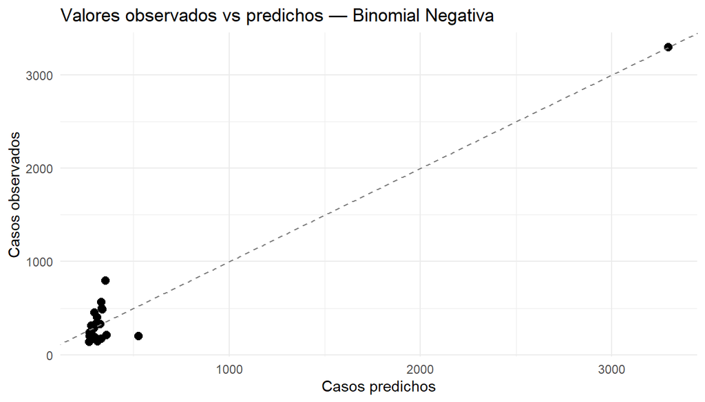

```r
ggplot(diagnostico_nb, aes(x = pred_nb, y = casos_divorcio)) +
  geom_point(size = 2.5) +
  geom_abline(slope = 1, intercept = 0,
              linetype = "dashed", color = "gray50") +
  labs(
    title = "Valores observados vs predichos — Binomial Negativa",
    x     = "Casos predichos",
    y     = "Casos observados"
  ) +
  theme_minimal()
```

El gráfico compara los valores observados de divorcios contra los predichos por el modelo para cada departamento. La línea discontinua representa la **predicción perfecta** — entre más cerca esté un punto de ella, mejor es la predicción del modelo para ese departamento.

Se observan dos grupos claramente diferenciados. El primero es la nube de puntos concentrada en la esquina inferior izquierda, que corresponde a los 21 departamentos del interior del país con volúmenes relativamente bajos de divorcios. El modelo los predice con razonable precisión, aunque con cierta dispersión alrededor de la línea diagonal. El segundo es el punto aislado en la esquina superior derecha, que corresponde al **Departamento de Guatemala** con 3,295 divorcios observados y predichos su predicción es prácticamente perfecta gracias a la variable dummy `es_capital`.

La dispersión en los departamentos del interior refleja que con solo dos predictores y 22 observaciones, el modelo no puede capturar todos los factores específicos de cada departamento como el acceso a juzgados, las barreras culturales o el nivel económico que también influyen en cuántos divorcios se formalizan. Esto es una limitación esperada y consistente con el tamaño del dataset.

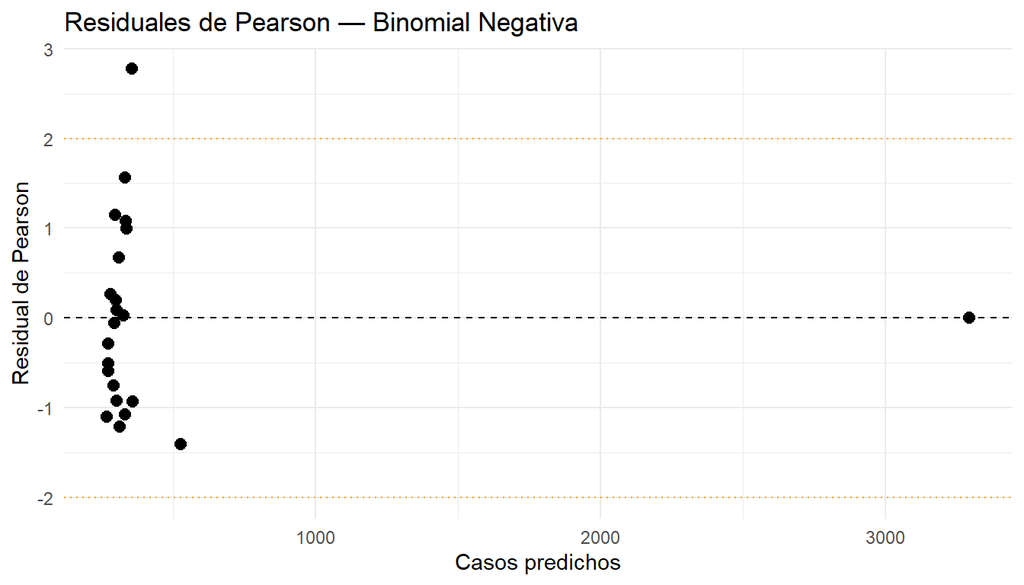

```r
ggplot(diagnostico_nb, aes(x = pred_nb, y = residuo_pearson_nb)) +
  geom_point(size = 2.5) +
  geom_hline(yintercept =  0, linetype = "dashed") +
  geom_hline(yintercept =  c(-2, 2), linetype = "dotted",
             color = "orange") +
  labs(
    title = "Residuales de Pearson — Binomial Negativa",
    x     = "Casos predichos",
    y     = "Residual de Pearson"
  ) +
  theme_minimal()
```

El gráfico de residuales de Pearson evalúa el ajuste del modelo revisando si los errores tienen algún patrón sistemático. La línea discontinua central representa residual cero predicción perfecta y las líneas punteadas naranjas marcan el umbral ±2, dentro del cual se considera que el ajuste es aceptable.

La gran mayoría de departamentos se encuentran dentro del rango ±2, lo que indica que el modelo ajusta razonablemente bien para el interior del país. Se observa una ligera asimetría: varios departamentos presentan residuales negativos, lo que significa que el modelo tiende a **sobreestimar** levemente el número de divorcios en esos casos. Esto puede explicarse porque algunos departamentos con alta violencia registrada tienen menos divorcios formalizados de lo esperado, posiblemente por barreras de acceso a los juzgados o factores culturales que desincentivan la disolución legal del matrimonio.

En términos generales, la ausencia de un patrón sistemático claro en los residuales como una curva o un embudo confirma que el modelo Binomial Negativo es una especificación adecuada para estos datos y que la sobredispersión está siendo correctamente absorbida por el parámetro θ del modelo.

```r
stopifnot(exists("metricas_nb"))
stopifnot(exists("modelo_nb_final"))
stopifnot(exists("pred_nb_final"))
stopifnot(exists("diagnostico_nb"))
stopifnot(nrow(metricas_nb) >= 3)
cat("Binomial Negativa OK — modelo final:", mejor_nb_nombre, "\n")
```

```
## Binomial Negativa OK — modelo final: NB_1
```

## Modelo de referencia: Regresión Poisson

La Regresión Poisson se incluye como modelo de referencia por ser el punto de partida estadístico natural para variables de conteo. Sin embargo, la razón de dispersión obtenida confirma la presencia de sobredispersión severa, lo que viola el supuesto central de Poisson (igualdad entre media y varianza). Sus resultados se interpretan únicamente como línea base frente al modelo principal de Regresión Binomial Negativa, que parametriza explícitamente esta sobredispersión.

Esta sección no representa un cuarto algoritmo seleccionado en el proceso de modelado, sino una referencia estadística que fundamenta empíricamente la elección de la Binomial Negativa como modelo principal.

```r
objetos_requeridos_pois <- c(
  "datos_modelo", "calcular_metricas", "metricas_nb", "modelo_nb_final"
)

for (obj in objetos_requeridos_pois) {
  if (!exists(obj)) {
    stop(paste("Debe ejecutarse primero el paso 01. Falta:", obj))
  }
}
```

```r
formula_pois_1 <- casos_divorcio ~ casos_violencia_z + es_capital

formula_pois_2 <- casos_divorcio ~ casos_violencia_z + es_capital + porc_urbano_z

formula_pois_3 <- casos_divorcio ~ casos_violencia_z * es_capital

formula_pois_4 <- casos_divorcio ~ casos_violencia_z + es_capital +
                  porc_urbano_z + edad_victima_prom_z
```

Se definen exactamente las mismas cuatro fórmulas utilizadas en la Binomial Negativa. Esto garantiza que cualquier diferencia en las métricas se atribuye exclusivamente a la familia distribucional y no a cambios en la especificación del modelo.

```r
modelo_pois_1 <- glm(formula_pois_1, data = datos_modelo, family = poisson(link = "log"))
modelo_pois_2 <- glm(formula_pois_2, data = datos_modelo, family = poisson(link = "log"))
modelo_pois_3 <- glm(formula_pois_3, data = datos_modelo, family = poisson(link = "log"))
modelo_pois_4 <- glm(formula_pois_4, data = datos_modelo, family = poisson(link = "log"))
```

Se ajustan los cuatro modelos Poisson sobre el dataset completo. Estos objetos se usan para calcular AIC, BIC y la razón de dispersión de Pearson.

```r
calcular_dispersion_poisson <- function(modelo) {
  sum(residuals(modelo, type = "pearson")^2) / modelo$df.residual
}

dispersion_poisson <- tibble(
  modelo     = c("POIS_1", "POIS_2", "POIS_3", "POIS_4"),
  dispersion = c(
    calcular_dispersion_poisson(modelo_pois_1),
    calcular_dispersion_poisson(modelo_pois_2),
    calcular_dispersion_poisson(modelo_pois_3),
    calcular_dispersion_poisson(modelo_pois_4)
  )
)

dispersion_poisson %>%
  kable(digits = 3, caption = "Razón de dispersión en modelos Poisson")
```

Razón de dispersión en modelos Poisson

| modelo | dispersion |
| --- | --- |
| POIS_1 | 84.688 |
| POIS_2 | 88.864 |
| POIS_3 | 84.688 |
| POIS_4 | 95.743 |

La razón de dispersión de Pearson mide cuántas veces más variable son los datos respecto a lo que Poisson predice. Un valor igual a 1 indica ajuste perfecto; valores sustancialmente mayores a 1 evidencian sobredispersión. Cuando existe sobredispersión, Poisson subestima los errores estándar y produce intervalos de confianza demasiado estrechos, lo que infla artificialmente la significancia estadística de los coeficientes. Esto refuerza la elección de la Regresión Binomial Negativa como modelo principal, ya que esta familia parametriza explícitamente la sobredispersión mediante el parámetro θ.

```r
loo_poisson <- function(formula_modelo, datos) {
  n <- nrow(datos)
  predicciones <- numeric(n)

  for (i in seq_len(n)) {
    entrenamiento   <- datos[-i, , drop = FALSE]
    prueba          <- datos[i, , drop = FALSE]
    modelo          <- glm(formula_modelo, data = entrenamiento, family = poisson(link = "log"))
    predicciones[i] <- predict(modelo, newdata = prueba, type = "response")
  }

  list(
    metricas     = calcular_metricas(datos$casos_divorcio, predicciones),
    predicciones = predicciones
  )
}
```

Se define la función `loo_poisson` con la misma estructura que `loo_nb`. En cada iteración entrena con 21 departamentos y predice el restante, devolviendo las métricas MAE, RMSE y MAPE junto con el vector de predicciones.

```r
loo_pois_1 <- loo_poisson(formula_pois_1, datos_modelo)
loo_pois_2 <- loo_poisson(formula_pois_2, datos_modelo)
loo_pois_3 <- loo_poisson(formula_pois_3, datos_modelo)
loo_pois_4 <- loo_poisson(formula_pois_4, datos_modelo)

pred_loo_pois <- list(
  POIS_1 = loo_pois_1$predicciones,
  POIS_2 = loo_pois_2$predicciones,
  POIS_3 = loo_pois_3$predicciones,
  POIS_4 = loo_pois_4$predicciones
)
```

Se corre LOOCV para cada variante Poisson. Las predicciones se almacenan en la lista `pred_loo_pois` para uso en la comparación final entre algoritmos.

```r
metricas_poisson <- bind_rows(
  loo_pois_1$metricas %>% mutate(modelo = "POIS_1",
    formula = paste(deparse(formula_pois_1), collapse = " ")),
  loo_pois_2$metricas %>% mutate(modelo = "POIS_2",
    formula = paste(deparse(formula_pois_2), collapse = " ")),
  loo_pois_3$metricas %>% mutate(modelo = "POIS_3",
    formula = paste(deparse(formula_pois_3), collapse = " ")),
  loo_pois_4$metricas %>% mutate(modelo = "POIS_4",
    formula = paste(deparse(formula_pois_4), collapse = " "))
) %>%
  mutate(
    AIC        = c(AIC(modelo_pois_1), AIC(modelo_pois_2), AIC(modelo_pois_3), AIC(modelo_pois_4)),
    BIC        = c(BIC(modelo_pois_1), BIC(modelo_pois_2), BIC(modelo_pois_3), BIC(modelo_pois_4)),
    dispersion = dispersion_poisson$dispersion,
    algoritmo  = "Regresión Poisson",
    rol        = "Referencia"
  ) %>%
  select(algoritmo, rol, modelo, formula, AIC, BIC, dispersion, MAE, RMSE, MAPE)

metricas_poisson %>%
  arrange(MAE, RMSE, AIC) %>%
  kable(digits = 3, caption = "Comparación de modelos Poisson")
```

Comparación de modelos Poisson

| algoritmo | rol | modelo | formula | AIC | BIC | dispersion | MAE | RMSE | MAPE |
| --- | --- | --- | --- | --- | --- | --- | --- | --- | --- |
| Regresión Poisson | Referencia | POIS_1 | casos_divorcio ~ casos_violencia_z + es_capital | 1668.408 | 1671.681 | 84.688 | 305.308 | 672.319 | 79.283 |
| Regresión Poisson | Referencia | POIS_3 | casos_divorcio ~ casos_violencia_z * es_capital | 1668.408 | 1671.681 | 84.688 | 305.308 | 672.319 | 79.283 |
| Regresión Poisson | Referencia | POIS_2 | casos_divorcio ~ casos_violencia_z + es_capital + porc_urbano_z | 1666.627 | 1670.991 | 88.864 | 332.428 | 722.469 | 92.412 |
| Regresión Poisson | Referencia | POIS_4 | casos_divorcio ~ casos_violencia_z + es_capital + porc_urbano_z + edad_victima_prom_z | 1660.340 | 1665.796 | 95.743 | 342.383 | 745.780 | 93.717 |

La tabla compara las cuatro variantes del modelo Poisson ordenadas de menor a mayor MAE bajo LOOCV. La columna `dispersion` confirma sobredispersión severa en todos los modelos. Los valores de AIC y BIC de Poisson son considerablemente más altos que los de la Binomial Negativa, lo que cuantifica el costo de ignorar la sobredispersión en términos de ajuste del modelo. El modelo con mejor desempeño predictivo según el LOOCV se selecciona como referencia final.

```r
mejor_pois_nombre <- metricas_poisson %>%
  arrange(MAE, RMSE, AIC) %>%
  slice(1) %>%
  pull(modelo)

modelo_poisson_final <- switch(
  mejor_pois_nombre,
  "POIS_1" = modelo_pois_1,
  "POIS_2" = modelo_pois_2,
  "POIS_3" = modelo_pois_3,
  "POIS_4" = modelo_pois_4
)

pred_poisson_final     <- predict(modelo_poisson_final, newdata = datos_modelo, type = "response")
metricas_poisson_final <- calcular_metricas(datos_modelo$casos_divorcio, pred_poisson_final)
```

```r
diagnostico_poisson <- datos_modelo %>%
  select(cod_depto, casos_divorcio) %>%
  mutate(
    pred_poisson            = pred_poisson_final,
    residuo_pearson_poisson = residuals(modelo_poisson_final, type = "pearson")
  )

diagnostico_poisson %>%
  kable(digits = 3, caption = "Diagnóstico del modelo Poisson de referencia")
```

Diagnóstico del modelo Poisson de referencia

| cod_depto | casos_divorcio | pred_poisson | residuo_pearson_poisson |
| --- | --- | --- | --- |
| 1 | 3295 | 3295.000 | 0.000 |
| 2 | 179 | 308.682 | -7.381 |
| 3 | 174 | 326.171 | -8.426 |
| 4 | 210 | 341.748 | -7.127 |
| 5 | 497 | 327.951 | 9.335 |
| 6 | 316 | 308.803 | 0.410 |
| 7 | 137 | 286.508 | -8.833 |
| 8 | 201 | 289.503 | -5.202 |
| 9 | 794 | 339.662 | 24.652 |
| 10 | 485 | 328.589 | 8.629 |
| 11 | 331 | 322.577 | 0.469 |
| 12 | 565 | 326.615 | 13.190 |
| 13 | 450 | 305.014 | 8.302 |
| 14 | 314 | 294.240 | 1.152 |
| 15 | 145 | 315.017 | -9.579 |
| 16 | 198 | 431.195 | -11.230 |
| 17 | 326 | 306.321 | 1.124 |
| 18 | 286 | 302.622 | -0.956 |
| 19 | 195 | 302.181 | -6.166 |
| 20 | 212 | 289.869 | -4.574 |
| 21 | 238 | 289.334 | -3.018 |
| 22 | 402 | 312.395 | 5.070 |

La tabla de diagnóstico presenta las predicciones del modelo Poisson de referencia y sus residuales de Pearson por departamento. Valores fuera del rango ±2 indican observaciones que el modelo no puede ajustar correctamente. Comparar estos residuales con los de la Binomial Negativa permite visualizar directamente el efecto de la sobredispersión: bajo Poisson, los residuales tienden a ser más extremos y con mayor dispersión, reflejando que el modelo subestima la varianza real de los datos.

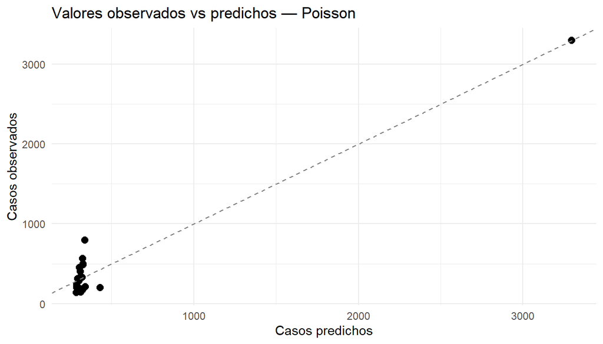

```r
ggplot(diagnostico_poisson, aes(x = pred_poisson, y = casos_divorcio)) +
  geom_point(size = 2.5) +
  geom_abline(slope = 1, intercept = 0, linetype = "dashed", color = "gray50") +
  labs(
    title = "Valores observados vs predichos — Poisson",
    x     = "Casos predichos",
    y     = "Casos observados"
  ) +
  theme_minimal()
```

El gráfico compara los valores observados de divorcios contra los predichos por el modelo Poisson de referencia. Al igual que en la Binomial Negativa, se observan dos grupos: la nube de departamentos del interior en la esquina inferior izquierda y el Departamento de Guatemala como punto aislado a la derecha. La diferencia clave respecto a la Binomial Negativa se manifestará en los residuales: Poisson, al no parametrizar la sobredispersión, genera predicciones que pueden ser similares en valor esperado pero con mayor incertidumbre subestimada.

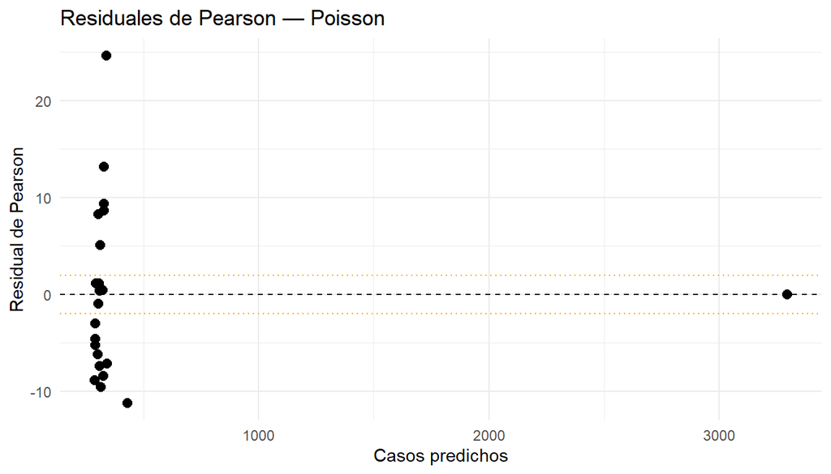

```r
ggplot(diagnostico_poisson, aes(x = pred_poisson, y = residuo_pearson_poisson)) +
  geom_point(size = 2.5) +
  geom_hline(yintercept = 0,        linetype = "dashed") +
  geom_hline(yintercept = c(-2, 2), linetype = "dotted", color = "orange") +
  labs(
    title = "Residuales de Pearson — Poisson",
    x     = "Casos predichos",
    y     = "Residual de Pearson"
  ) +
  theme_minimal()
```

El gráfico de residuales de Pearson del modelo Poisson es la evidencia más directa de la sobredispersión. A diferencia del modelo Binomial Negativo, se espera que más departamentos presenten residuales fuera del rango ±2 y que la magnitud de los valores extremos sea mayor. Esto ocurre porque Poisson asume que la varianza es igual a la media: cuando la varianza real es mucho mayor, el modelo produce residuales estandarizados inflados. La comparación visual entre este gráfico y el equivalente de la Binomial Negativa constituye la evidencia gráfica más clara de por qué la Binomial Negativa es el modelo adecuado para estos datos.

```r
stopifnot(exists("metricas_nb"))
stopifnot(exists("metricas_poisson"))
stopifnot(exists("modelo_poisson_final"))
stopifnot(exists("pred_poisson_final"))
stopifnot(nrow(metricas_poisson) >= 3)
cat("Poisson (referencia) OK — modelo final:", mejor_pois_nombre, "\n")
```

```
## Poisson (referencia) OK — modelo final: POIS_1
```

## Modelo de apoyo: Random Forest

Random Forest se incorpora como modelo de apoyo para comparar el enfoque estadístico principal (Regresión Binomial Negativa) frente a un método no lineal de aprendizaje automático. Permite evaluar si aparecen relaciones no lineales y revisar la **importancia relativa** de los predictores mediante permutación. **No sustituye** al modelo principal: la Binomial Negativa sigue siendo la especificación más adecuada para conteos con sobredispersión y ofrece interpretación más directa en escala de tasas esperadas.

Se entrena como **regresión** sobre `casos_divorcio` en su escala original (sin log), con las mismas variables estandarizadas que en los modelos GLM, se excluye `cod_depto` del entrenamiento y la evaluación predictiva usa **LOOCV** para mantener consistencia con NB y Poisson. Con $n = 22$ departamentos, la configuración de hiperparámetros es deliberadamente conservadora para limitar el sobreajuste.

```r
objetos_requeridos_rf <- c(
  "datos_modelo", "calcular_metricas", "metricas_nb", "metricas_poisson"
)

for (obj in objetos_requeridos_rf) {
  if (!exists(obj)) {
    stop(paste("Debe ejecutarse primero el paso anterior. Falta:", obj))
  }
}
```

```r
datos_rf <- datos_modelo %>%
  select(
    casos_divorcio,
    casos_violencia_z,
    edad_victima_prom_z,
    porc_urbano_z,
    es_capital
  )

if (!"casos_divorcio" %in% names(datos_rf)) {
  stop("datos_rf debe contener la variable respuesta casos_divorcio.")
}

if (nrow(datos_rf) != nrow(datos_modelo)) {
  stop("datos_rf tiene distinto número de filas que datos_modelo. Verificar la preparación.")
}

predictores_rf <- setdiff(names(datos_rf), "casos_divorcio")
```

El objeto `datos_rf` replica las 22 filas de `datos_modelo` y solo incluye la respuesta y predictores numéricos (más la dummy `es_capital`), sin identificador departamental, para que el bosque no aprenda patrones espurios a partir de códigos administrativos.

```r
loo_rf <- function(datos, mtry_valor, min_node_size_valor, num_trees_valor) {
  n            <- nrow(datos)
  predicciones <- numeric(n)

  for (i in seq_len(n)) {
    entrenamiento   <- datos[-i, , drop = FALSE]
    prueba          <- datos[i, , drop = FALSE]

    modelo <- ranger(
      casos_divorcio ~ .,
      data           = entrenamiento,
      num.trees      = num_trees_valor,
      mtry           = mtry_valor,
      min.node.size  = min_node_size_valor,
      importance     = "permutation",
      seed           = 123
    )

    predicciones[i] <- predict(modelo, data = prueba)$predictions
  }

  list(
    metricas = calcular_metricas(datos$casos_divorcio, predicciones) %>%
      mutate(
        mtry          = mtry_valor,
        min_node_size = min_node_size_valor,
        num_trees     = num_trees_valor
      ),
    predicciones = predicciones
  )
}
```

```r
mtry_base <- max(1, floor(sqrt(length(predictores_rf))))

loo_rf_1 <- loo_rf(datos_rf, mtry_valor = mtry_base,
                   min_node_size_valor = 3, num_trees_valor = 300)

loo_rf_2 <- loo_rf(datos_rf, mtry_valor = max(1, mtry_base - 1),
                   min_node_size_valor = 4, num_trees_valor = 500)

loo_rf_3 <- loo_rf(datos_rf, mtry_valor = min(length(predictores_rf), mtry_base + 1),
                   min_node_size_valor = 2, num_trees_valor = 500)

pred_loo_rf <- list(
  RF_1 = loo_rf_1$predicciones,
  RF_2 = loo_rf_2$predicciones,
  RF_3 = loo_rf_3$predicciones
)

metricas_rf <- bind_rows(
  loo_rf_1$metricas %>% mutate(modelo = "RF_1"),
  loo_rf_2$metricas %>% mutate(modelo = "RF_2"),
  loo_rf_3$metricas %>% mutate(modelo = "RF_3")
) %>%
  mutate(
    algoritmo = "Random Forest",
    rol       = "Apoyo"
  ) %>%
  select(algoritmo, rol, modelo, mtry, min_node_size, num_trees, MAE, RMSE, MAPE)

metricas_rf %>%
  arrange(MAE, RMSE) %>%
  kable(digits = 3, caption = "Comparación de modelos Random Forest (LOOCV)")
```

Comparación de modelos Random Forest (LOOCV)

| algoritmo | rol | modelo | mtry | min_node_size | num_trees | MAE | RMSE | MAPE |
| --- | --- | --- | --- | --- | --- | --- | --- | --- |
| Random Forest | Apoyo | RF_3 | 3 | 2 | 500 | 300.120 | 661.341 | 75.201 |
| Random Forest | Apoyo | RF_2 | 1 | 4 | 500 | 301.877 | 668.170 | 75.212 |
| Random Forest | Apoyo | RF_1 | 2 | 3 | 300 | 307.793 | 665.297 | 77.588 |

La tabla resume tres configuraciones que difieren en `mtry`, `min.node.size` y número de árboles. La variante con menor **MAE** y **RMSE** bajo LOOCV se adopta como Random Forest final; si dos filas empatan, el orden `arrange(MAE, RMSE)` prioriza el error absoluto medio.

```r
mejor_rf <- metricas_rf %>%
  arrange(MAE, RMSE) %>%
  slice(1)

modelo_rf_final <- ranger(
  casos_divorcio ~ .,
  data          = datos_rf,
  num.trees     = mejor_rf$num_trees,
  mtry          = mejor_rf$mtry,
  min.node.size = mejor_rf$min_node_size,
  importance    = "permutation",
  seed          = 123
)

pred_rf_final     <- predict(modelo_rf_final, data = datos_rf)$predictions
metricas_rf_final <- calcular_metricas(datos_rf$casos_divorcio, pred_rf_final)
```

```r
diagnostico_rf <- datos_modelo %>%
  select(cod_depto, casos_divorcio) %>%
  mutate(pred_rf = pred_rf_final)

diagnostico_rf %>%
  kable(digits = 3, caption = "Predicciones del modelo Random Forest final por departamento")
```

Predicciones del modelo Random Forest final por departamento

| cod_depto | casos_divorcio | pred_rf |
| --- | --- | --- |
| 1 | 3295 | 2125.349 |
| 2 | 179 | 228.292 |
| 3 | 174 | 304.661 |
| 4 | 210 | 323.432 |
| 5 | 497 | 459.001 |
| 6 | 316 | 328.707 |
| 7 | 137 | 360.830 |
| 8 | 201 | 250.361 |
| 9 | 794 | 573.675 |
| 10 | 485 | 459.975 |
| 11 | 331 | 339.350 |
| 12 | 565 | 476.578 |
| 13 | 450 | 394.351 |
| 14 | 314 | 313.666 |
| 15 | 145 | 204.933 |
| 16 | 198 | 264.367 |
| 17 | 326 | 378.837 |
| 18 | 286 | 285.284 |
| 19 | 195 | 206.618 |
| 20 | 212 | 233.076 |
| 21 | 238 | 247.769 |
| 22 | 402 | 340.639 |

La tabla alinea `cod_depto` desde `datos_modelo` con las predicciones del bosque; el orden de filas coincide con `datos_rf` porque ambos provienen del mismo `datos_modelo` sin reordenar.

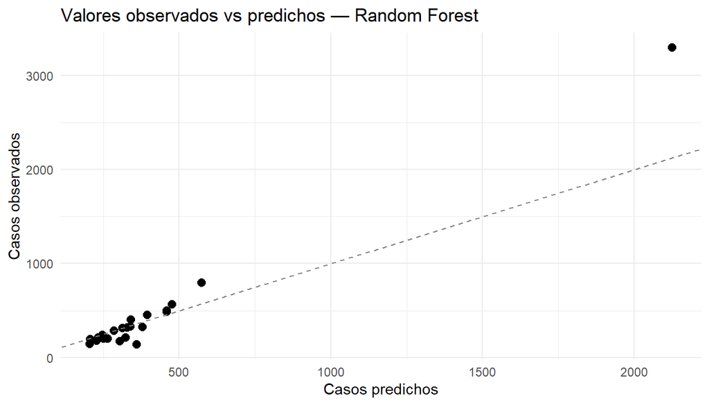

Valores observados frente a predichos para Random Forest (ajuste en muestra completa). La línea discontinua es predicción perfecta.

```r
ggplot(diagnostico_rf, aes(x = pred_rf, y = casos_divorcio)) +
  geom_point(size = 2.5) +
  geom_abline(slope = 1, intercept = 0, linetype = "dashed", color = "gray50") +
  labs(
    title = "Valores observados vs predichos — Random Forest",
    x     = "Casos predichos",
    y     = "Casos observados"
  ) +
  theme_minimal()
```

El gráfico usa la misma escala que NB y Poisson (divorcios observados vs predichos). Random Forest puede ajustar mejor algunos puntos del interior si existen interacciones no modeladas por los GLM, pero con $n$ tan pequeño las diferencias deben interpretarse con cautela.

```r
importancia_rf <- tibble(
  variable    = names(modelo_rf_final$variable.importance),
  importancia = as.numeric(modelo_rf_final$variable.importance)
) %>%
  arrange(desc(importancia))

importancia_rf %>%
  kable(digits = 3, caption = "Importancia de variables en Random Forest (permutación)")
```

Importancia de variables en Random Forest (permutación)

| variable | importancia |
| --- | --- |
| casos_violencia_z | 13975.365 |
| es_capital | 0.000 |
| edad_victima_prom_z | -4107.243 |
| porc_urbano_z | -4310.927 |

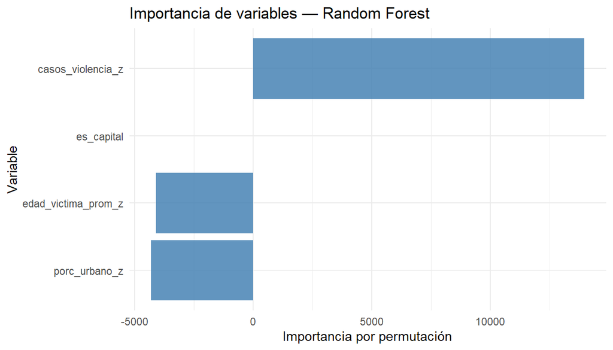

Importancia por permutación en el Random Forest final (mayor valor = más contribución al error cuando la variable se permuta).

```r
ggplot(importancia_rf, aes(x = reorder(variable, importancia), y = importancia)) +
  geom_col(fill = "steelblue", alpha = 0.85) +
  coord_flip() +
  labs(
    title = "Importancia de variables — Random Forest",
    x     = "Variable",
    y     = "Importancia por permutación"
  ) +
  theme_minimal()
```

Tras ejecutar el documento, la variable con mayor importancia de permutación indica qué predictor el bosque usa con más intensidad para reducir el error de predicción. Si **`es_capital`** y/o **`casos_violencia_z`** lideran la importancia, el resultado es coherente con la Regresión Binomial Negativa, donde la dummy metropolitana y el volumen de violencia concentran buena parte de la explicación a nivel departamental. Si otra variable gana claramente, sugiere que Random Forest está captando estructura adicional (por ejemplo, combinaciones no lineales con urbanización o edad) que el GLM lineal en los predictores no incorpora; ello no invalida el modelo principal, pero enriquece la lectura exploratoria.

Dado el tamaño muestral, Random Forest tiene **mayor riesgo de ajuste específico a estos 22 puntos** que la Binomial Negativa; por eso se mantiene como apoyo y no como modelo de decisión principal.

```r
stopifnot(exists("metricas_rf"))
stopifnot(exists("modelo_rf_final"))
stopifnot(exists("pred_rf_final"))
stopifnot(exists("diagnostico_rf"))
stopifnot(nrow(metricas_rf) >= 3)
stopifnot(nrow(datos_rf) == nrow(datos_modelo))
cat("Random Forest (apoyo) OK — configuración final: mtry =", mejor_rf$mtry,
    ", min.node.size =", mejor_rf$min_node_size,
    ", num.trees =", mejor_rf$num_trees, "\n")
```

```
## Random Forest (apoyo) OK — configuración final: mtry = 3 , min.node.size = 2 , num.trees = 500
```

## Benchmark predictivo: XGBoost

XGBoost se incluye como benchmark predictivo para contrastar el desempeño de los modelos estadísticos contra un método de aprendizaje automático más flexible. Se utiliza el objetivo `count:poisson` para mantener coherencia con la naturaleza de conteo de la variable respuesta y garantizar predicciones no negativas. Se emplearon hiperparámetros conservadores para reducir el riesgo de sobreajuste, que es especialmente alto con n = 22. Un mejor error en LOOCV no implica automáticamente que XGBoost sea el modelo más adecuado, ya que la interpretabilidad y el fundamento estadístico también son criterios relevantes para la selección final.

```r
objetos_requeridos_xgb <- c(
  "datos_modelo", "calcular_metricas",
  "metricas_nb", "metricas_poisson", "metricas_rf"
)

for (obj in objetos_requeridos_xgb) {
  if (!exists(obj)) {
    stop(paste("Debe ejecutarse primero el paso anterior. Falta:", obj))
  }
}
```

```r
datos_xgb <- datos_modelo %>%
  select(
    casos_divorcio,
    casos_violencia_z,
    edad_victima_prom_z,
    porc_urbano_z,
    es_capital
  )

if (nrow(datos_xgb) != nrow(datos_modelo)) {
  stop("datos_xgb tiene distinto número de filas que datos_modelo. Verificar la preparación.")
}

x_xgb <- datos_xgb %>%
  select(-casos_divorcio) %>%
  as.matrix()

y_xgb <- datos_xgb$casos_divorcio
```

Al igual que con Random Forest, se excluye `cod_depto` de los predictores para evitar que el modelo aprenda patrones espurios a partir de identificadores administrativos. El orden de filas se mantiene idéntico al de `datos_modelo` para garantizar la alineación correcta de predicciones en la comparación final.

```r
loo_xgb <- function(x, y, params, nrounds_valor) {
  n            <- length(y)
  predicciones <- numeric(n)

  for (i in seq_len(n)) {
    x_train <- x[-i, , drop = FALSE]
    y_train <- y[-i]
    x_test  <- x[i, , drop = FALSE]

    dtrain <- xgb.DMatrix(data = x_train, label = y_train)
    dtest  <- xgb.DMatrix(data = x_test)

    modelo <- xgb.train(
      params  = params,
      data    = dtrain,
      nrounds = nrounds_valor,
      verbose = 0
    )

    predicciones[i] <- predict(modelo, dtest)
  }

  predicciones <- pmax(predicciones, 0)

  list(
    metricas     = calcular_metricas(y, predicciones),
    predicciones = predicciones
  )
}
```

La función `loo_xgb` sigue la misma estructura que `loo_nb` y `loo_rf`: en cada iteración entrena con 21 departamentos y predice el restante, acumulando predicciones que luego se usan para calcular MAE, RMSE y MAPE. El `pmax(..., 0)` asegura que ninguna predicción sea negativa, lo cual no debería ocurrir con `count:poisson` pero se aplica como salvaguarda.

```r
params_xgb_1 <- list(
  objective        = "count:poisson",
  eval_metric      = "rmse",
  max_depth        = 1,
  eta              = 0.05,
  subsample        = 1,
  colsample_bytree = 1,
  min_child_weight = 1
)

params_xgb_2 <- list(
  objective        = "count:poisson",
  eval_metric      = "rmse",
  max_depth        = 2,
  eta              = 0.05,
  subsample        = 0.9,
  colsample_bytree = 0.9,
  min_child_weight = 2
)

params_xgb_3 <- list(
  objective        = "count:poisson",
  eval_metric      = "rmse",
  max_depth        = 2,
  eta              = 0.10,
  subsample        = 0.8,
  colsample_bytree = 0.8,
  min_child_weight = 2
)

loo_xgb_1 <- loo_xgb(x_xgb, y_xgb, params_xgb_1, nrounds_valor = 50)
loo_xgb_2 <- loo_xgb(x_xgb, y_xgb, params_xgb_2, nrounds_valor = 75)
loo_xgb_3 <- loo_xgb(x_xgb, y_xgb, params_xgb_3, nrounds_valor = 50)

pred_loo_xgb <- list(
  XGB_1 = loo_xgb_1$predicciones,
  XGB_2 = loo_xgb_2$predicciones,
  XGB_3 = loo_xgb_3$predicciones
)

metricas_xgb <- bind_rows(
  loo_xgb_1$metricas %>% mutate(
    modelo = "XGB_1", max_depth = 1, eta = 0.05,
    subsample = 1.0, colsample_bytree = 1.0, min_child_weight = 1, nrounds = 50
  ),
  loo_xgb_2$metricas %>% mutate(
    modelo = "XGB_2", max_depth = 2, eta = 0.05,
    subsample = 0.9, colsample_bytree = 0.9, min_child_weight = 2, nrounds = 75
  ),
  loo_xgb_3$metricas %>% mutate(
    modelo = "XGB_3", max_depth = 2, eta = 0.10,
    subsample = 0.8, colsample_bytree = 0.8, min_child_weight = 2, nrounds = 50
  )
) %>%
  mutate(
    algoritmo = "XGBoost",
    rol       = "Benchmark predictivo"
  ) %>%
  select(
    algoritmo, rol, modelo,
    max_depth, eta, subsample, colsample_bytree, min_child_weight, nrounds,
    MAE, RMSE, MAPE
  )

metricas_xgb %>%
  arrange(MAE, RMSE) %>%
  kable(digits = 3, caption = "Comparación de modelos XGBoost (LOOCV)")
```

Comparación de modelos XGBoost (LOOCV)

| algoritmo | rol | modelo | max_depth | eta | subsample | colsample_bytree | min_child_weight | nrounds | MAE | RMSE | MAPE |
| --- | --- | --- | --- | --- | --- | --- | --- | --- | --- | --- | --- |
| XGBoost | Benchmark predictivo | XGB_1 | 1 | 0.05 | 1.0 | 1.0 | 1 | 50 | 272.926 | 653.256 | 60.615 |
| XGBoost | Benchmark predictivo | XGB_3 | 2 | 0.10 | 0.8 | 0.8 | 2 | 50 | 284.620 | 683.506 | 62.307 |
| XGBoost | Benchmark predictivo | XGB_2 | 2 | 0.05 | 0.9 | 0.9 | 2 | 75 | 287.375 | 684.457 | 66.244 |

Se evalúan tres configuraciones con hiperparámetros deliberadamente conservadores. XGB_1 usa árboles de profundidad 1 (tocones) que solo realizan una partición binaria por árbol, lo que minimiza el sobreajuste en datasets pequeños. XGB_2 y XGB_3 aumentan ligeramente la complejidad a profundidad 2 con distintas tasas de aprendizaje y subsampling. Con n = 22, incluso árboles de profundidad 2 pueden capturar patrones espurios, por lo que las métricas LOOCV son la referencia más honesta para comparar las variantes.

```r
mejor_xgb <- metricas_xgb %>%
  arrange(MAE, RMSE) %>%
  slice(1)

params_xgb_final <- list(
  objective        = "count:poisson",
  eval_metric      = "rmse",
  max_depth        = mejor_xgb$max_depth,
  eta              = mejor_xgb$eta,
  subsample        = mejor_xgb$subsample,
  colsample_bytree = mejor_xgb$colsample_bytree,
  min_child_weight = mejor_xgb$min_child_weight
)

dtrain_xgb_final <- xgb.DMatrix(data = x_xgb, label = y_xgb)

modelo_xgb_final <- xgb.train(
  params  = params_xgb_final,
  data    = dtrain_xgb_final,
  nrounds = mejor_xgb$nrounds,
  verbose = 0
)

pred_xgb_final     <- pmax(predict(modelo_xgb_final, dtrain_xgb_final), 0)
metricas_xgb_final <- calcular_metricas(y_xgb, pred_xgb_final)
```

El modelo final se entrena sobre el dataset completo usando la configuración con menor MAE bajo LOOCV. Las predicciones en muestra completa (`pred_xgb_final`) se usan exclusivamente para el diagnóstico visual y la comparación por departamento en la sección siguiente; las métricas de generalización provienen del LOOCV.

```r
diagnostico_xgb <- datos_modelo %>%
  select(cod_depto, casos_divorcio) %>%
  mutate(pred_xgb = pred_xgb_final)

diagnostico_xgb %>%
  kable(digits = 3, caption = "Predicciones del modelo XGBoost final por departamento")
```

Predicciones del modelo XGBoost final por departamento

| cod_depto | casos_divorcio | pred_xgb |
| --- | --- | --- |
| 1 | 3295 | 1995.454 |
| 2 | 179 | 346.317 |
| 3 | 174 | 346.317 |
| 4 | 210 | 393.926 |
| 5 | 497 | 393.926 |
| 6 | 316 | 346.317 |
| 7 | 137 | 346.317 |
| 8 | 201 | 346.317 |
| 9 | 794 | 393.926 |
| 10 | 485 | 393.926 |
| 11 | 331 | 346.317 |
| 12 | 565 | 393.926 |
| 13 | 450 | 346.317 |
| 14 | 314 | 346.317 |
| 15 | 145 | 346.317 |
| 16 | 198 | 393.926 |
| 17 | 326 | 346.317 |
| 18 | 286 | 346.317 |
| 19 | 195 | 346.317 |
| 20 | 212 | 346.317 |
| 21 | 238 | 346.317 |
| 22 | 402 | 346.317 |

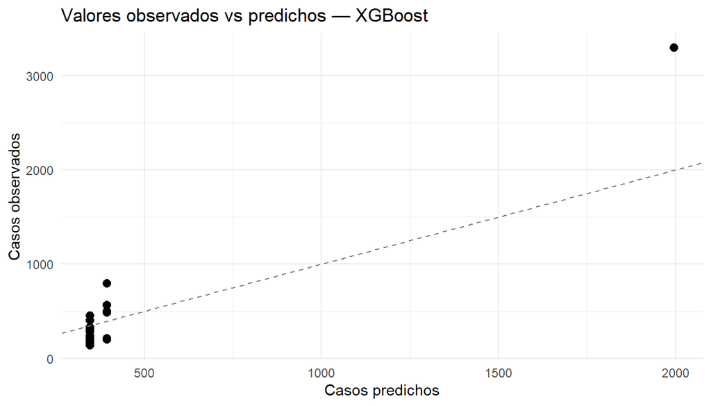

Valores observados frente a predichos para XGBoost (ajuste en muestra completa). La línea discontinua es predicción perfecta.

```r
ggplot(diagnostico_xgb, aes(x = pred_xgb, y = casos_divorcio)) +
  geom_point(size = 2.5) +
  geom_abline(slope = 1, intercept = 0, linetype = "dashed", color = "gray50") +
  labs(
    title = "Valores observados vs predichos — XGBoost",
    x     = "Casos predichos",
    y     = "Casos observados"
  ) +
  theme_minimal()
```

```r
importancia_xgb <- xgb.importance(
  feature_names = colnames(x_xgb),
  model         = modelo_xgb_final
)

importancia_xgb %>%
  as_tibble() %>%
  kable(digits = 3, caption = "Importancia de variables en XGBoost (Gain)")
```

Importancia de variables en XGBoost (Gain)

| Feature | Gain | Cover | Frequency |
| --- | --- | --- | --- |
| casos_violencia_z | 1 | 1 | 1 |

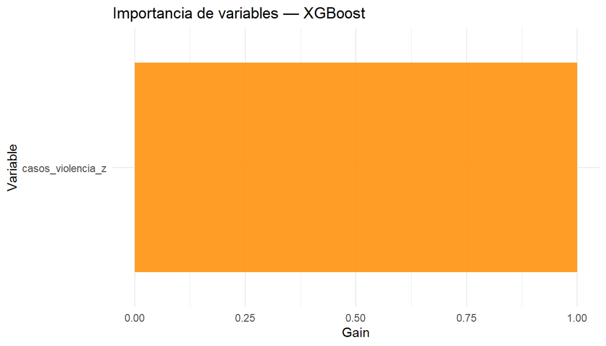

Importancia de variables en XGBoost medida por Gain. Mayor valor indica mayor contribución a la reducción del error en los splits del árbol.

```r
importancia_xgb %>%
  as_tibble() %>%
  ggplot(aes(x = reorder(Feature, Gain), y = Gain)) +
  geom_col(fill = "darkorange", alpha = 0.85) +
  coord_flip() +
  labs(
    title = "Importancia de variables — XGBoost",
    x     = "Variable",
    y     = "Gain"
  ) +
  theme_minimal()
```

La importancia por Gain mide cuánto reduce el error de predicción cada variable cuando se usa en un split, promediado sobre todos los árboles. Si `es_capital` y `casos_violencia_z` lideran tanto en XGBoost como en Random Forest, esto refuerza la solidez del análisis: dos métodos con arquitecturas distintas convergen en identificar los mismos predictores como los más informativos. Una discrepancia entre ambos señalaría que XGBoost está aprovechando interacciones no lineales que el bosque no captura con igual profundidad, lo cual enriquece la lectura exploratoria sin invalidar el modelo principal.

```r
stopifnot(exists("metricas_xgb"))
stopifnot(exists("modelo_xgb_final"))
stopifnot(exists("pred_xgb_final"))
stopifnot(exists("diagnostico_xgb"))
stopifnot(nrow(metricas_xgb) >= 3)
stopifnot(nrow(datos_xgb) == nrow(datos_modelo))
cat("XGBoost (benchmark) OK — configuración final: max_depth =", mejor_xgb$max_depth,
    ", eta =", mejor_xgb$eta,
    ", nrounds =", mejor_xgb$nrounds, "\n")
```

```
## XGBoost (benchmark) OK — configuración final: max_depth = 1 , eta = 0.05 , nrounds = 50
```